# Recalling Words

#### Background

Many teachers and other educators are interested in understanding how to best deliver new content to students. In general, they have two choices of how to do this.

1. The Meshed Approach
   - Deliver new content while simultaneously reviewing previously understood content.
2. The Before Approach
   - Deliver new content after fully reviewing previously understood content.

A study was performed to determine whether the *Meshed* or *Before* approaches to delivering content had any positive benefits on memory recall.

##### The Experiment (click to view)

#### Hypotheses

The null hypothesis is that there is not a significant difference in medians between the two methods, Meshed and Before, and the alternative is that there is a difference between them. Formally written as,

$H_0:$ difference in medians $= 0$

$H_a:$ difference in medians $\neq 0$

with $\alpha = 0.05$

#### Analysis

To check the distribution of our data a box plot was shown below.

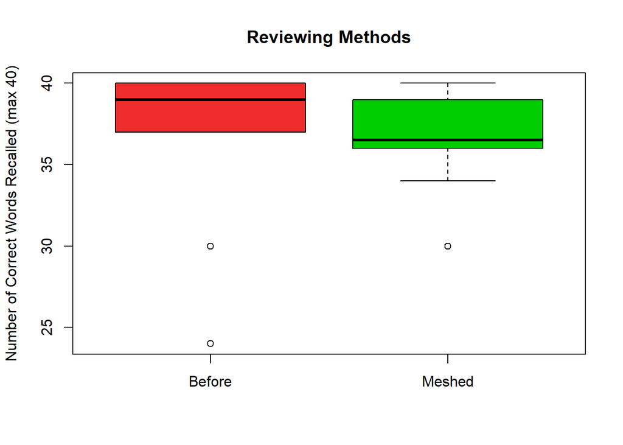

```r
boxplot(correct ~ condition, data = Rtypes, main = "Reviewing Methods", ylab = "Number of Correct Words Recalled (max 40)", col = c("firebrick2", "green3"))
```

The medians are

| Method | Before | Meshed |
| --- | --- | --- |
| Median | 39.0 | 36.5 |

After looking closer at the data we also observed that both data sets have a lot of ties. A table below shows the numbers and the number of ties in the data set. (note that the number of ties are only from the Meshed and Before data. SRF was not considered because the null is only comparing the medians of Before to Meshed)

| Observed Value | 24 | 30 | 34 | 36 | 37 | 38 | 39 | 40 |
| --- | --- | --- | --- | --- | --- | --- | --- | --- |
| Number of Ties | 1 | 2 | 1 | 3 | 2 | 2 | 4 | 5 |

To compensate for the amount of ties in the data a continuity correction was done and the results are as follows.

```r
pander(wilcox.test(correct ~ condition, data=Rtypes, mu=0, alternative="two.sided", conf.level=0.95))
```

Wilcoxon rank sum test with continuity correction: `correct` by `condition`

| Test statistic | P value | Alternative hypothesis |
| --- | --- | --- |
| 62 | 0.378 | two.sided |

The test statistic was $W = 62$ which gave a p-value of 0.378. Comparing our $p$-value to $\alpha$ we get:
$$(p = 0.378 > \alpha)$$
Therefore, we have insufficient evidence to reject the null hypothesis.

#### Interpretation

The results of the study shows a lack of evidence to favor anyone method over the other. However, both Meshed and Before still appear to be a valid options for reviewing material, this analysis only shows that Before is not significantly better than Meshed and vice versa.

The Wilcoxon test is not without its weaknesses. Due to the large amount of ties within the data we are unaware of just how much it might have affected the results.

The study did not make any observations with how the subjects felt about the method. One method might have caused more stress or uneasiness than the other. Further studies could potentialy look into which method provides the smoothest transition into a higher level classes.

##### Source

Friendly, M. and Franklin, P. (1980) Interactive presentation in multitrial free recall. Memory and Cognition 8 265–270 [Personal communication from M. Friendly].

##### References

Fox, J. (2008) Applied Regression Analysis and Generalized Linear Models, Second Edition. Sage.

Fox, J. and Weisberg, S. (2011) An R Companion to Applied Regression, Second Edition, Sage.